# Arrival and Departure Final Models with Traits Included

This is a cleaned version of dredge_trait_models Changes

- species and region as random effects (not year)
- scaling temperature values
- setting nACQ to 0, see why [here](https://stats.stackexchange.com/questions/77313/why-cant-i-match-glmer-family-binomial-output-with-manual-implementation-of-g).

```r
load(here::here("Data","Spp_master","spp_master_ztemp_seus_buoy.traits.RData"))
```

[output not shown]

I will be looking at:

*trophic level* maximum age *age at maturity* maximum body size

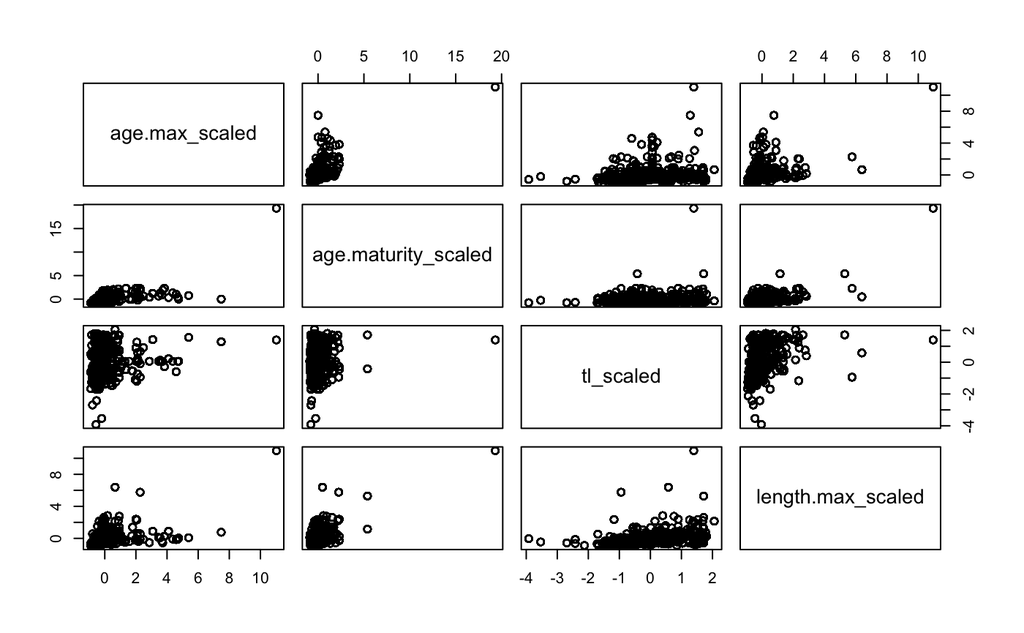

Prep for dredge

```r
tempvars
```

```
  [1] "mean_sst_temp_scaled"                 "max_sst_temp_scaled"
  [3] "min_sst_temp_scaled"                  "seas_sst_temp_scaled"
  [5] "max_sst_temp_lag1_scaled"             "max_sst_temp_lag2_scaled"
  [7] "max_sst_temp_lag3_scaled"             "max_sst_temp_lag4_scaled"
  [9] "max_sst_temp_lag5_scaled"             "max_sst_temp_lag6_scaled"
 [11] "max_sst_temp_lag7_scaled"             "max_sst_temp_lag8_scaled"
 [13] "max_sst_temp_lag9_scaled"             "max_sst_temp_lag10_scaled"
 [15] "mean_sst_temp_lag1_scaled"            "mean_sst_temp_lag2_scaled"
 [17] "mean_sst_temp_lag3_scaled"            "mean_sst_temp_lag4_scaled"
 [19] "mean_sst_temp_lag5_scaled"            "mean_sst_temp_lag6_scaled"
 [21] "mean_sst_temp_lag7_scaled"            "mean_sst_temp_lag8_scaled"
 [23] "mean_sst_temp_lag9_scaled"            "mean_sst_temp_lag10_scaled"
 [25] "min_sst_temp_lag1_scaled"             "min_sst_temp_lag2_scaled"
 [27] "min_sst_temp_lag3_scaled"             "min_sst_temp_lag4_scaled"
 [29] "min_sst_temp_lag5_scaled"             "min_sst_temp_lag6_scaled"
```

[output cut: 109 more lines]

#run later tonight

Making all models for arrival

```r
#playing with year as factor
#can't get dredge to run above, so trying here with fewer variables
arrival.reduced[,year := as.factor(year)]

#for now, going with two traits and one temp variable
#going to make loop to make all models I need to look at with single variables
all.temp.variables <- colnames(arrival.reduced[,9:256])
all.temp.variables.0 <- c(0, all.temp.variables) #add 0 as option so models can just include traits
all.temp.variables.0 <- all.temp.variables.0[!grepl("*mean*", all.temp.variables.0)]#get rid of MEAN temp variables
all.trait.variables <- c(0, "tl_scaled", "age.max_scaled","age.maturity_scaled", "length.max_scaled",
                         "tl_scaled + age.max_scaled", "age.max_scaled + tl_scaled",
                         "tl_scaled + age.maturity_scaled", "age.maturity_scaled + tl_scaled",
                         "tl_scaled + length.max_scaled", "length.max_scaled + tl_scaled",
                         "age.max_scaled + age.maturity_scaled", "age.maturity_scaled + age.max_scaled",
                         "age.max_scaled + length.max_scaled", "length.max_scaled + age.max_scaled",
                         "age.maturity_scaled + length.max_scaled", "length.max_scaled + age.maturity_scaled")

sign <- c("+", "*")

full_var_set <- as.data.table(expand.grid(all.temp.variables.0, sign, all.trait.variables))

arrival_model_comparison_traits <- as.data.table(matrix(nrow = nrow(full_var_set)))
arrival_model_comparison_traits[, temp_variable:=as.factor(V1)][, sign:=as.factor(V1)][, trait_variable:=as.factor(V1)][, AICc:=as.numeric(V1)][, converge:= as.logical(V1)]
arrival_model_comparison_traits[, V1 := NULL]

for (i in 1:nrow(full_var_set)){

  temp <- full_var_set$Var1[i]
  sign <- full_var_set$Var2[i]
  trait <- full_var_set$Var3[i]

  formula <- as.formula(paste("col ~", temp, sign, trait, "+ (1|reg) + (1|spp)"))

  mod <- glmer(formula, family = binomial, data = arrival.reduced, nAGQ = 0)

  arrival_model_comparison_traits[i,temp_variable := full_var_set$Var1[i]]
  arrival_model_comparison_traits[i,sign := full_var_set$Var2[i]]
  arrival_model_comparison_traits[i,trait_variable := full_var_set$Var3[i]]
  arrival_model_comparison_traits[i,AICc := AICc(mod)]

  warning <- mod@optinfo$conv$lme4$messages[2]
  converges <- ifelse(is.null(warning) == TRUE, T, F)

  arrival_model_comparison_traits[i, converge := converges]

  print(paste(i, nrow(arrival_model_comparison_traits), sep = "/"))

}


saveRDS(arrival_model_comparison_traits, here::here("Model_results","Traits","arrival_model_comparison_traits.rds"))
```

Making all models for departure

```r
#for now, going with two traits and one temp variable
#going to make loop to make all models I need to look at with single variables
#don't want mean

departure_model_comparison_traits <- as.data.table(matrix(nrow = nrow(full_var_set)))
departure_model_comparison_traits[, temp_variable:=as.factor(V1)][, sign:=as.factor(V1)][, trait_variable:=as.factor(V1)][, AICc:=as.numeric(V1)][, converge:= as.logical(V1)]
departure_model_comparison_traits[, V1 := NULL]

for (i in 1:nrow(full_var_set)){

  temp <- full_var_set$Var1[i]
  sign <- full_var_set$Var2[i]
  trait <- full_var_set$Var3[i]

  formula <- as.formula(paste("now_ext ~", temp, sign, trait, "+ (1|reg) + (1|spp)"))

  mod <- glmer(formula, family = binomial, data = departure.reduced, nAGQ = 0)

  departure_model_comparison_traits[i,temp_variable := full_var_set$Var1[i]]
  departure_model_comparison_traits[i,sign := full_var_set$Var2[i]]
  departure_model_comparison_traits[i,trait_variable := full_var_set$Var3[i]]
  departure_model_comparison_traits[i,AICc := AICc(mod)]

  warning <- mod@optinfo$conv$lme4$messages[2]
  converges <- ifelse(is.null(warning) == TRUE, T, F)

  departure_model_comparison_traits[i, converge := converges]

  print(paste(i, nrow(departure_model_comparison_traits), sep = "/"))

}

saveRDS(departure_model_comparison_traits, here::here("Model_results","Traits","departure_model_comparison_traits.rds"))
```

Next step is to look at RVI (relative variable importance)

RVI for Temperature Trait Arrival Models

```r
#only raw temp has lag of 10 years, which means variable importance comparisons are unbalanced so I will get rid of these rows
colonization_model_comparisons_traits.lag9max <- colonization_model_comparison_traits[!grepl("lag10", temp_variable), ]

#add ∆AIC to tables
min_col_AICc_trait <- min(colonization_model_comparisons_traits.lag9max[, AICc])
colonization_model_comparisons_traits.lag9max[,"deltaAICc" := (AICc - min_col_AICc_trait)]

#add relative likelihood exp( -0.5 * ∆AIC score for that model)
colonization_model_comparisons_traits.lag9max[,"rel_likelihood" := exp((-0.5 * deltaAICc))]
#sum relative likelihoods across all models
colonization_model_comparisons_traits.lag9max.likelihoodsum <- sum(colonization_model_comparisons_traits.lag9max[, rel_likelihood])
#Akaike weight for a model is this rel_likelihood devided by the sum of these values across all models
colonization_model_comparisons_traits.lag9max[,"akaike_weight" := rel_likelihood/colonization_model_comparisons_traits.lag9max.likelihoodsum]

#I want to look at relative importance FOR
#bottom/surface (bottom = includes sbt, grepl("sbt", variable))
col_bottom_importance <- sum(colonization_model_comparisons_traits.lag9max[grep("sbt", temp_variable), ]$akaike_weight)
col_surface_importance <- sum(colonization_model_comparisons_traits.lag9max[grep("sst", temp_variable), ]$akaike_weight)
  col_bottom_importance.n <- count(colonization_model_comparisons_traits.lag9max[grepl("sbt", temp_variable), ]) #3060
  col_surface_importance.n <- count(colonization_model_comparisons_traits.lag9max[grepl("sst", temp_variable), ]) #3060

#lag/not lagged (grepl("lag", variable))
col_lag_importance <- sum(colonization_model_comparisons_traits.lag9max[grep("lag", temp_variable), ]$akaike_weight)
col_nolag_importance <- sum(colonization_model_comparisons_traits.lag9max[!grep("lag", temp_variable), ]$akaike_weight)
  col_lag_importance.n <- count(colonization_model_comparisons_traits.lag9max[grepl("lag", temp_variable), ]) #5508 models include a lag
  col_nolag_importance.n <- count(colonization_model_comparisons_traits.lag9max[!grepl("lag", temp_variable), ]) #646 don't include a lag (no lag OR trait only)


  #34 models have NO temp variable


#absolute (grepl("abs", variable))
col_abs_importance <- sum(colonization_model_comparisons_traits.lag9max[grep("abs", temp_variable), ]$akaike_weight)
  col_abs_importance.n <- count(colonization_model_comparisons_traits.lag9max[grepl("abs", temp_variable), ])#2040

#raw (!grepl("change"))
col_raw_importance <- sum(colonization_model_comparisons_traits.lag9max[!grep("change", temp_variable), ][temp_variable != 0,]$akaike_weight)
  col_raw_importance.n <- count(colonization_model_comparisons_traits.lag9max[!grepl("change", temp_variable), ][temp_variable != 0]) #2040

#change (grepl("change", temp_variable), (!grepl("abs")))
col_change_importance <- sum(colonization_model_comparisons_traits.lag9max[grep("change", temp_variable), ][!grep("abs", temp_variable),]$akaike_weight)
  col_change_importance.n <- count(colonization_model_comparisons_traits.lag9max[grep("change", temp_variable), ][!grep("abs", temp_variable),])#2040


#type of temp temp_variable (max, min, seas)
col_max_temp_importance <- sum(colonization_model_comparisons_traits.lag9max[grep("max", temp_variable), ]$akaike_weight)
col_min_temp_importance <- sum(colonization_model_comparisons_traits.lag9max[grep("min", temp_variable), ]$akaike_weight)
col_seas_temp_importance <- sum(colonization_model_comparisons_traits.lag9max[grep("seas", temp_variable), ]$akaike_weight)
  col_max_temp_importance.n <- count(colonization_model_comparisons_traits.lag9max[grepl("max", temp_variable), ]) #2040
  col_min_temp_importance.n <- count(colonization_model_comparisons_traits.lag9max[grepl("min", temp_variable), ]) #2040
  col_seas_temp_importance.n <- count(colonization_model_comparisons_traits.lag9max[grepl("seas", temp_variable), ]) #2040


#traits included
col_age.max_importance <- sum(colonization_model_comparisons_traits.lag9max[grep("age.max", trait_variable), ]$akaike_weight)
col_age.maturity_importance <- sum(colonization_model_comparisons_traits.lag9max[grep("age.maturity", trait_variable), ]$akaike_weight)
col_tl_importance <- sum(colonization_model_comparisons_traits.lag9max[grep("tl", trait_variable), ]$akaike_weight)
col_length.max_importance <- sum(colonization_model_comparisons_traits.lag9max[grep("length", trait_variable),]$akaike_weight)
  col_age.max_importance.n <- count(colonization_model_comparisons_traits.lag9max[grepl("age.max", trait_variable), ]) #2534
  col_age.maturity_importance.n <- count(colonization_model_comparisons_traits.lag9max[grepl("age.maturity", trait_variable), ]) #2534
  col_tl_importance.n <- count(colonization_model_comparisons_traits.lag9max[grepl("tl", trait_variable), ]) #2534
  col_length.max_importance.n <- count(colonization_model_comparisons_traits.lag9max[grepl("length", trait_variable),]) #2534


#interaction between trait and temperature
col_interaction_temp_trait_importance <- sum(colonization_model_comparisons_traits.lag9max[grep("\\*", sign), ]$akaike_weight)
  col_interaction_temp_trait_importance.n <- count(colonization_model_comparisons_traits.lag9max[grepl("\\*", sign), ]) #3077


#save this table
save(colonization_model_comparisons_traits.lag9max, file = "colonization_models_traits_with_likelihoods.Rdata")
```

```r
arrival_departure <- c("arrival","arrival","arrival","arrival","arrival", "arrival","arrival", "arrival", "arrival","arrival", "arrival","arrival", "arrival", "arrival","arrival")
type <- c("depth", "depth", "lag", "lag", "Change?", "Change?", "Change?", "Temp", "Temp", "Temp", "Trait", "Trait", "Trait","Trait", "Interaction")
variable <- c("bottom", "surface", "no_lag", "lagged", "absolute_value_change", "change", "raw", "Min", "Max", "Seas", "age.max", "age.maturity", "tl", "length.max", "tempxtrait")
value <- c(arrival_bottom_importance, arrival_surface_importance, arrival_nolag_importance, arrival_lag_importance, arrival_abs_importance, arrival_change_importance, arrival_raw_importance, arrival_min_temp_importance, arrival_max_temp_importance, arrival_seas_temp_importance, arrival_age.max_importance, arrival_age.maturity_importance, arrival_tl_importance, arrival_length.max_importance, arrival_interaction_temp_trait_importance)

RVI_arrival_traits <- data.table(arrival_departure, type, variable, value)
```

Departure

```r
#only raw temp has lag of 10 years, which means variable importance comparisons are unbalanced so I will get rid of these rows
departure_model_comparisons_traits.lag9max <- departure_model_comparison_traits[!grepl("lag10", temp_variable), ]


#add ∆AIC to tables
min_departure_AICc_trait <- min(departure_model_comparisons_traits.lag9max[, AICc])
departure_model_comparisons_traits.lag9max[,"deltaAICc" := (AICc - min_departure_AICc_trait)]

#add relative likelihood exp( -0.5 * ∆AIC score for that model)
departure_model_comparisons_traits.lag9max[,"rel_likelihood" := exp((-0.5 * deltaAICc))]
#sum relative likelihoods across all models
departure_model_comparisons_traits.lag9max.likelihoodsum <- sum(departure_model_comparisons_traits.lag9max[, rel_likelihood])
#Akaike weight for a model is this rel_likelihood devided by the sum of these values across all models
departure_model_comparisons_traits.lag9max[,"akaike_weight" := rel_likelihood/departure_model_comparisons_traits.lag9max.likelihoodsum]

#I want to look at relative importance FOR
#bottom/surface (bottom = includes sbt, grepl("sbt", variable))
departure_bottom_importance <- sum(departure_model_comparisons_traits.lag9max[grep("sbt", temp_variable), ]$akaike_weight)
  departure_bottom_importance.n <- count(departure_model_comparisons_traits.lag9max[grepl("sbt", temp_variable), ]) #3060
departure_surface_importance <- sum(departure_model_comparisons_traits.lag9max[grep("sst", temp_variable), ]$akaike_weight)
  departure_surface_importance.n <- count(departure_model_comparisons_traits.lag9max[grepl("sst", temp_variable), ]) #3060

#lag/not lagged (grepl("lag", variable))
departure_lag_importance <- sum(departure_model_comparisons_traits.lag9max[grep("lag", temp_variable), ]$akaike_weight)
  departure_lag_importance.n <- count(departure_model_comparisons_traits.lag9max[grepl("lag", temp_variable),]) #5508
departure_nolag_importance <- sum(departure_model_comparisons_traits.lag9max[!grep("lag", temp_variable), ]$akaike_weight)
  departure_nolag_importance.n <- count(departure_model_comparisons_traits.lag9max[!grepl("lag", temp_variable), ]) #646

  #absolute (grepl("abs", variable))
departure_abs_importance <- sum(departure_model_comparisons_traits.lag9max[grep("abs", temp_variable), ]$akaike_weight)
  departure_abs_importance.n <- count(departure_model_comparisons_traits.lag9max[grepl("abs", temp_variable), ]) #2040

  #raw (!grepl("change"))
departure_raw_importance <- sum(departure_model_comparisons_traits.lag9max[!grep("change", temp_variable), ][temp_variable != 0,]$akaike_weight)
  departure_raw_importance.n <- count(departure_model_comparisons_traits.lag9max[!grepl("change", temp_variable), ][temp_variable != 0,]) #2040

#change (grepl("change", temp_variable), (!grepl("abs")))
departure_change_importance <- sum(departure_model_comparisons_traits.lag9max[grep("change", temp_variable), ][!grep("abs", temp_variable),]$akaike_weight)
  departure_change_importance.n <- count(departure_model_comparisons_traits.lag9max[grepl("change", temp_variable), ][!grepl("abs", temp_variable),])#2040

#type of temp temp_variable (max, min, seas)
departure_max_temp_importance <- sum(departure_model_comparisons_traits.lag9max[grep("max", temp_variable), ]$akaike_weight)
  departure_max_temp_importance.n <- count(departure_model_comparisons_traits.lag9max[grepl("max", temp_variable), ]) #2040
departure_min_temp_importance <- sum(departure_model_comparisons_traits.lag9max[grep("min", temp_variable), ]$akaike_weight)
  departure_min_temp_importance.n <- count(departure_model_comparisons_traits.lag9max[grepl("min", temp_variable), ]) #2040
departure_seas_temp_importance <- sum(departure_model_comparisons_traits.lag9max[grep("seas", temp_variable), ]$akaike_weight)
  departure_seas_temp_importance.n <- count(departure_model_comparisons_traits.lag9max[grepl("seas", temp_variable), ]) #2040

#traits included
departure_age.max_importance <- sum(departure_model_comparisons_traits.lag9max[grep("age.max", trait_variable), ]$akaike_weight)
departure_age.maturity_importance <- sum(departure_model_comparisons_traits.lag9max[grep("age.maturity", trait_variable), ]$akaike_weight)
departure_tl_importance <- sum(departure_model_comparisons_traits.lag9max[grep("tl", trait_variable), ]$akaike_weight)
departure_length.max_importance <- sum(departure_model_comparisons_traits.lag9max[grep("length", trait_variable),]$akaike_weight)

  departure_age.max_importance.n <- count(departure_model_comparisons_traits.lag9max[grepl("age.max", trait_variable), ]) #2534
  departure_age.maturity_importance.n <- count(departure_model_comparisons_traits.lag9max[grepl("age.maturity", trait_variable), ]) #2534
  departure_tl_importance.n <- count(departure_model_comparisons_traits.lag9max[grepl("tl", trait_variable), ]) #2534
  departure_length.max_importance.n <- count(departure_model_comparisons_traits.lag9max[grepl("length", trait_variable),]) #2534

#interaction between trait and temperature
departure_interaction_temp_trait_importance <- sum(departure_model_comparisons_traits.lag9max[grep("\\*", sign), ]$akaike_weight)
  departure_interaction_temp_trait_importance.n <- count(departure_model_comparisons_traits.lag9max[grepl("\\*", sign), ]) #3077


#save this table
saveRDS(departure_model_comparisons_traits.lag9max, here:here("Model_results","Traits","departure_models_traits_with_likelihoods.rds"))
```

```r
col_ext <- c("ext","ext","ext","ext","ext", "ext","ext", "ext", "ext","ext", "ext","ext", "ext", "ext","ext")
type <- c("depth", "depth", "lag", "lag", "Change?", "Change?", "Change?", "Temp", "Temp", "Temp", "Trait", "Trait", "Trait","Trait", "Interaction")
variable <- c("bottom", "surface", "no_lag", "lagged", "absolute_value_change", "change", "raw", "Min", "Max", "Seas", "age.max", "age.maturity", "tl", "length.max", "tempxtrait")
value <- c(ext_bottom_importance, ext_surface_importance, ext_nolag_importance, ext_lag_importance, ext_abs_importance, ext_change_importance, ext_raw_importance, ext_min_temp_importance, ext_max_temp_importance, ext_seas_temp_importance, ext_age.max_importance, ext_age.maturity_importance, ext_tl_importance, ext_length.max_importance, ext_interaction_temp_trait_importance)

RVI_ext_traits <- data.table(col_ext, type, variable, value)
```

Merge RVI tables for colonization and extinction with traits, and then graph

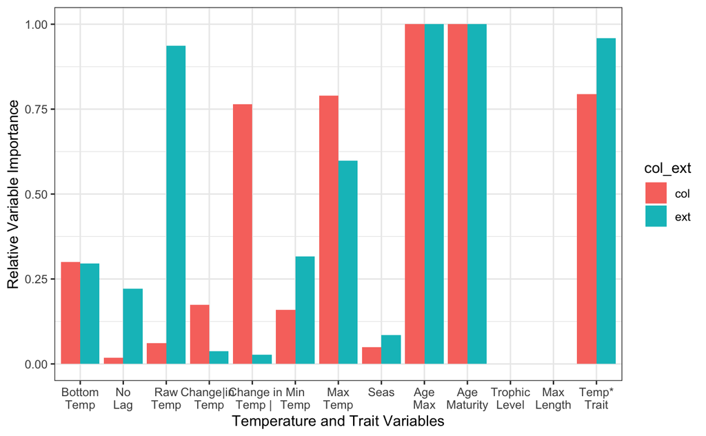

```r
RVI_trait_table <- as.data.table(rbind(RVI_col_traits, RVI_ext_traits)) #bind RVI for colonizations and extinctions

RVI_trait_table.r <- RVI_trait_table[!grep("surface", variable)][!grep("lagged", variable)]

#change order of factor levels
RVI_trait_table.r[, variable := factor(variable, levels = c("bottom", "no_lag", "raw", "change", "absolute_value_change", "Min", "Max", "Seas", "age.max", "age.maturity", "tl", "length.max", "tempxtrait"))]

save(RVI_trait_table, file = "RVI_trait_table.Rdata")

ggplot(data = RVI_trait_table.r, aes(x=variable, y = value, fill = col_ext)) +
  geom_bar(stat = "identity", position = "dodge") +
  scale_x_discrete(breaks = c("bottom", "no_lag", "raw", "change", "absolute_value_change", "Min", "Max", "Seas", "age.max", "age.maturity", "tl", "length.max", "tempxtrait"), labels = c("Bottom\nTemp", "No\nLag", "Raw\nTemp", "Change in \nTemp", "| Change in\n Temp |", "Min\nTemp", "Max\nTemp", "Seas", "Age\nMax", "Age\nMaturity", "Trophic\nLevel", "Max\nLength" , "Temp*\nTrait")) +
  labs(x = "Temperature and Trait Variables", y = "Relative Variable Importance")  +
  theme_bw()
```

Another way to visualize

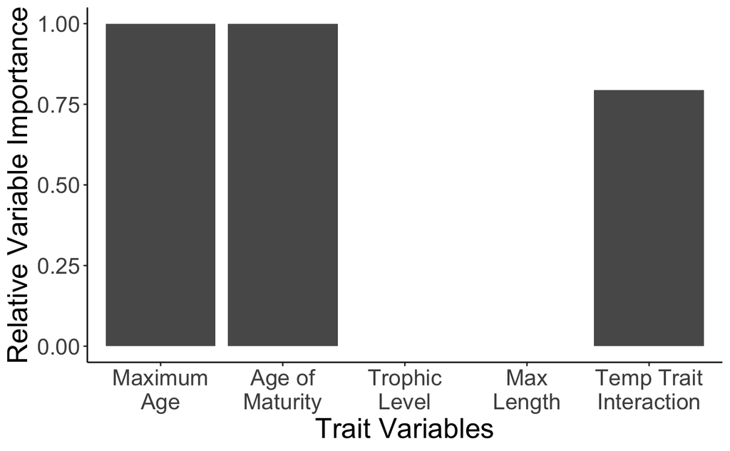

```r
#put levels into correct order for viewing
RVI_trait_table[
  , variable := factor(variable, levels = c("bottom", "surface", "absolute_value_change", "change", "raw", "no_lag", "lagged", "Min", "Max", "Seas", "age.max", "age.maturity", "tl","length.max", "tempxtrait"))][
    ,type := factor(type, levels = c("Change?", "depth", "lag", "Temp", "Trait", "Interaction"))]
#make types factors as well

#colonization
RVI_col_trait_plot <- ggplot(data = RVI_trait_table[col_ext == "col" & (type == "Trait" | type == "Interaction")], aes(x=variable, y = value)) +
  geom_bar(stat= "identity") +
  scale_x_discrete(breaks = c("age.max", "age.maturity", "tl", "length.max", "tempxtrait"), labels = c("Maximum\nAge", "Age of\nMaturity", "Trophic\nLevel","Max\nLength", "Temp Trait\nInteraction")) +
  labs(x = "Trait Variables", y = "Relative Variable Importance") +
  theme_classic() +
  theme(text = element_text(size = 20))
#extinction
RVI_ext_trait_plot <- ggplot(data = RVI_trait_table[col_ext == "ext" & (type == "Trait" | type == "Interaction")], aes(x=variable, y = value)) +
  geom_bar(stat= "identity") +
  scale_x_discrete(breaks = c("age.max", "age.maturity", "tl","length.max",  "tempxtrait"), labels = c("Maximum\nAge", "Age of\nMaturity", "Trophic\nLevel","Max\nLength", "Temp Trait\nInteraction")) +
  labs(x = "Trait Variables", y = "Relative Variable Importance") +
  theme_classic() +
  theme(text = element_text(size = 20))

RVI_col_trait_plot
```

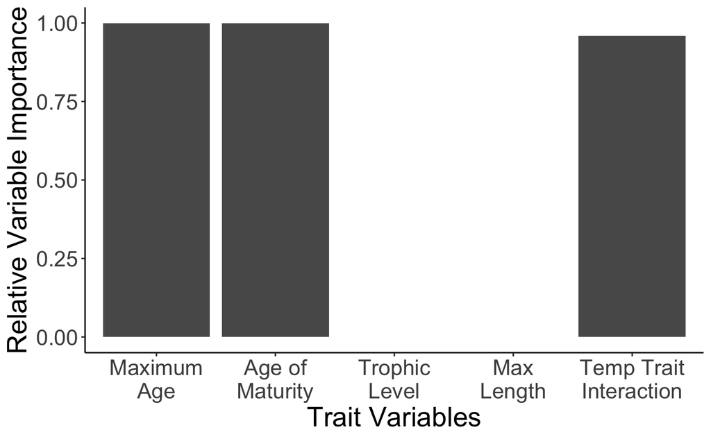

```r
RVI_ext_trait_plot
```

```r
save(RVI_trait_table, file = "RVI_trait_table.Rdata")
```

Let’s see how the RVI importance varies by looking at specific lag values for these trait models

```r
#first, table for lags
lags_v_RVI_trait <- data.table(col_lag = c(0:9), col_RVI = 0, ext_RVI = 0)
#colonization
lags_v_RVI_trait[1,2] <- 1-sum(colonization_model_comparisons_traits.lag9max[grep("lag", temp_variable), ]$akaike_weight)
lags_v_RVI_trait[2,2] <- sum(colonization_model_comparisons_traits.lag9max[grep("lag1", temp_variable), ]$akaike_weight)
lags_v_RVI_trait[3,2] <- sum(colonization_model_comparisons_traits.lag9max[grep("lag2", temp_variable), ]$akaike_weight)
lags_v_RVI_trait[4,2] <- sum(colonization_model_comparisons_traits.lag9max[grep("lag3", temp_variable), ]$akaike_weight)
lags_v_RVI_trait[5,2] <- sum(colonization_model_comparisons_traits.lag9max[grep("lag4", temp_variable), ]$akaike_weight)
lags_v_RVI_trait[6,2] <- sum(colonization_model_comparisons_traits.lag9max[grep("lag5", temp_variable), ]$akaike_weight)
lags_v_RVI_trait[7,2] <- sum(colonization_model_comparisons_traits.lag9max[grep("lag6", temp_variable), ]$akaike_weight)
lags_v_RVI_trait[8,2] <- sum(colonization_model_comparisons_traits.lag9max[grep("lag7", temp_variable), ]$akaike_weight)
lags_v_RVI_trait[9,2] <- sum(colonization_model_comparisons_traits.lag9max[grep("lag8", temp_variable), ]$akaike_weight)
lags_v_RVI_trait[10,2] <- sum(colonization_model_comparisons_traits.lag9max[grep("lag9", temp_variable), ]$akaike_weight)
#extinction
lags_v_RVI_trait[1,3] <- 1-sum(extinction_model_comparisons_traits.lag9max[grep("lag", temp_variable), ]$akaike_weight)
lags_v_RVI_trait[2,3] <- sum(extinction_model_comparisons_traits.lag9max[grep("lag1", temp_variable), ]$akaike_weight)
lags_v_RVI_trait[3,3] <- sum(extinction_model_comparisons_traits.lag9max[grep("lag2", temp_variable), ]$akaike_weight)
lags_v_RVI_trait[4,3] <- sum(extinction_model_comparisons_traits.lag9max[grep("lag3", temp_variable), ]$akaike_weight)
lags_v_RVI_trait[5,3] <- sum(extinction_model_comparisons_traits.lag9max[grep("lag4", temp_variable), ]$akaike_weight)
lags_v_RVI_trait[6,3] <- sum(extinction_model_comparisons_traits.lag9max[grep("lag5", temp_variable), ]$akaike_weight)
lags_v_RVI_trait[7,3] <- sum(extinction_model_comparisons_traits.lag9max[grep("lag6", temp_variable), ]$akaike_weight)
lags_v_RVI_trait[8,3] <- sum(extinction_model_comparisons_traits.lag9max[grep("lag7", temp_variable), ]$akaike_weight)
lags_v_RVI_trait[9,3] <- sum(extinction_model_comparisons_traits.lag9max[grep("lag8", temp_variable), ]$akaike_weight)
lags_v_RVI_trait[10,3] <- sum(extinction_model_comparisons_traits.lag9max[grep("lag9", temp_variable), ]$akaike_weight)

RVI_lags_traits <- ggplot(data = lags_v_RVI_trait, aes(x = col_lag)) +
  geom_line(aes(y = col_RVI)) +
  geom_line(aes(y = ext_RVI), linetype = "dashed") +
  labs(x = "Lag (years)", y = "Relative Variable Importance") +
  theme_classic() +
  theme(text = element_text(size = 22, color = "black")) +
  scale_x_continuous(breaks = 0:10) +
  scale_y_continuous(limits = 0:1)

save(RVI_col_trait_plot, RVI_ext_trait_plot, RVI_lags_traits, file = "RVI_plots_traits.Rdata")

setEPS()
postscript("RVI_col_trait_plot.eps")
RVI_col_trait_plot
dev.off()
```

```r
setEPS()
postscript("RVI_ext_trait_plot.eps")
```

```r
RVI_ext_trait_plot
dev.off()
```

```r
setEPS()
postscript("RVI_lags_trait_plot.eps")
```

```r
RVI_lags_traits
dev.off()
```

What do interactions look like?

##Colonization with Traits Best model: max_sst_temp_change_abs_lag1_scaled * age.maturity_scaled + age.max_scaled Best model with all species: seas_sst_temp_scaled * age.maturity_scaled + age.max_scaled

```r
library(ggfortify)
library(wesanderson)
pal <- wes_palette("GrandBudapest1", 5, type = "continuous")

#best model with fish only
mod_col_trait <- glmer(col ~ max_sst_temp_change_abs_lag1_scaled * age.maturity_scaled + age.max_scaled + (1|reg) + (1|spp), family = "binomial", data = colonization.reduced, nAGQ = 0)

#using best predictor for all species in model instead
mod_col_trait_allspp <- glmer(col ~ seas_sst_temp_scaled * age.maturity_scaled + age.max_scaled + (1|reg) + (1|spp), family = "binomial", data = colonization.reduced, nAGQ = 0)


#temp only col trait model seas_sst_temp_scaled
mod_col_trait_notraits <- glmer(col ~ seas_sst_temp_scaled + (1|reg) + (1|spp), family = "binomial", data = colonization.reduced, nAGQ = 0)
summary(mod_col_trait_notraits)
```

```
Generalized linear mixed model fit by maximum likelihood (Adaptive Gauss-Hermite
  Quadrature, nAGQ = 0) [glmerMod]
 Family: binomial  ( logit )
Formula: col ~ seas_sst_temp_scaled + (1 | reg) + (1 | spp)
   Data: colonization.reduced

     AIC      BIC   logLik deviance df.resid
  4266.6   4296.6  -2129.3   4258.6    13292

Scaled residuals:
    Min      1Q  Median      3Q     Max
-0.7102 -0.2223 -0.1264 -0.0969  8.5326

Random effects:
 Groups Name        Variance Std.Dev.
 spp    (Intercept) 1.8924   1.3756
 reg    (Intercept) 0.9617   0.9807
Number of obs: 13296, groups:  spp, 382; reg, 9

Fixed effects:
                     Estimate Std. Error z value Pr(>|z|)
(Intercept)           -3.9990     0.3512 -11.388  < 2e-16 ***
seas_sst_temp_scaled  -0.4284     0.1303  -3.289  0.00101 **
---
Signif. codes:  0 ‘***’ 0.001 ‘**’ 0.01 ‘*’ 0.05 ‘.’ 0.1 ‘ ’ 1

Correlation of Fixed Effects:
            (Intr)
ss_sst_tmp_ 0.180
```

```r
#trait only col trait model
mod_col_trait_notemp <- glmer(col ~ age.maturity_scaled + age.max_scaled + (1|reg) + (1|spp), family = "binomial", data = colonization.reduced, nAGQ = 0)
summary(mod_col_trait_notemp)
```

```
Generalized linear mixed model fit by maximum likelihood (Adaptive Gauss-Hermite
  Quadrature, nAGQ = 0) [glmerMod]
 Family: binomial  ( logit )
Formula: col ~ age.maturity_scaled + age.max_scaled + (1 | reg) + (1 |      spp)
   Data: colonization.reduced

     AIC      BIC   logLik deviance df.resid
  3898.7   3935.9  -1944.4   3888.7    12424

Scaled residuals:
    Min      1Q  Median      3Q     Max
-0.6280 -0.2246 -0.1239 -0.0968  8.4475

Random effects:
 Groups Name        Variance Std.Dev.
 spp    (Intercept) 1.8873   1.3738
 reg    (Intercept) 0.3326   0.5767
Number of obs: 12429, groups:  spp, 354; reg, 9

Fixed effects:
                    Estimate Std. Error z value Pr(>|z|)
(Intercept)          -3.7991     0.2248 -16.902  < 2e-16 ***
age.maturity_scaled   0.2737     0.1500   1.824  0.06809 .
age.max_scaled       -0.5907     0.1927  -3.064  0.00218 **
---
Signif. codes:  0 ‘***’ 0.001 ‘**’ 0.01 ‘*’ 0.05 ‘.’ 0.1 ‘ ’ 1

Correlation of Fixed Effects:
            (Intr) ag.mt_
ag.mtrty_sc -0.064
age.mx_scld  0.082 -0.745
```

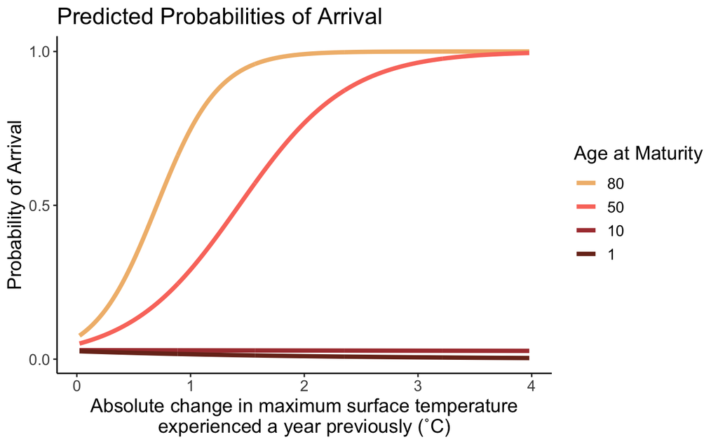

```r
#reverse to agematurity unscaled
mod_col_reverse_scaled_agematurity <- lm(age.maturity ~ age.maturity_scaled, data = spp_master_ztemp_seus_buoy.traits_scaled)

mod_col_forward_scaled_agematurity <- lm(age.maturity_scaled ~ age.maturity, data = spp_master_ztemp_seus_buoy.traits_scaled)

age_match <- data.table(ages_we_want = c(1, 10, 50, 80))
age_match[,age.maturity_scaled := ages_we_want * mod_col_forward_scaled_agematurity$coefficients[2]+mod_col_forward_scaled_agematurity$coefficients[1]]

#best predictor for fish only: max_sst_temp_change_abs_lag1_scaled as x axis
temp_col_newdata <- runif(500,min(spp_master_ztemp_seus_buoy.traits_scaled$max_sst_temp_change_abs_lag1_scaled), max(spp_master_ztemp_seus_buoy.traits_scaled$max_sst_temp_change_abs_lag1_scaled))

temp_agematurity_newdata <- age_match[,age.maturity_scaled]


temp_agemax_newdata <- mean(spp_master_ztemp_seus_buoy.traits_scaled$age.max_scaled, na.rm = T)

col_newdata_traits <- expand.grid("max_sst_temp_change_abs_lag1_scaled" = temp_col_newdata, "age.maturity_scaled" = temp_agematurity_newdata, "age.max_scaled" = temp_agemax_newdata)


preds <- predict(mod_col_trait, newdata = col_newdata_traits, re.form = NA, type = "response")
preds_predictors <- data.table(cbind(col_newdata_traits, preds))
preds_predictors <- preds_predictors[age_match, on = "age.maturity_scaled"]

#I want x axis to be meaningful
mod_col_reverse_scaledtemp <- lm(max_sst_temp_change_abs_lag1 ~ max_sst_temp_change_abs_lag1_scaled, data = spp_master_ztemp_seus_buoy.traits_scaled)


preds_predictors[,max_sst_temp_change_abs_lag1 := mod_col_reverse_scaledtemp$coefficients[2]*max_sst_temp_change_abs_lag1_scaled + mod_col_reverse_scaledtemp$coefficients[1] ]

#reverse order of ages to match
preds_predictors$ages_we_want <- factor(preds_predictors$ages_we_want, levels=c("80", "50", "10", "1"))


ggplot(data = preds_predictors, aes(x = max_sst_temp_change_abs_lag1, y = preds, color = as.factor(ages_we_want))) +
  geom_line(size = 1.5) +
  labs(colour="Age at Maturity", x = "Absolute change in maximum surface temperature\nexperienced a year previously (˚C)", y = "Probability of Arrival",title = "Predicted Probabilities of Arrival") +
  scale_y_continuous(breaks=c(0, 0.5, 1)) +
  theme_classic() +
  scale_color_manual(values = pal) +
  theme(text=element_text(size = 14))

ggsave(path = "plots/marginal_effects", file = "predicted_probs_col_maxage.jpg")
```

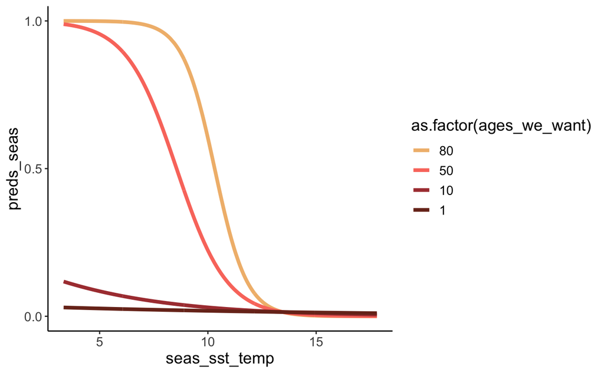

```r
#best predictor for all organisms: seasonality as x axis
temp_col_newdata_seas <- runif(500,min(spp_master_ztemp_seus_buoy.traits_scaled$seas_sst_temp_scaled), max(spp_master_ztemp_seus_buoy.traits_scaled$seas_sst_temp_scaled))

temp_agematurity_newdata_seas <- age_match[,age.maturity_scaled]


temp_agemax_newdata_seas <- mean(spp_master_ztemp_seus_buoy.traits_scaled$age.max_scaled, na.rm = T)

col_newdata_traits_seas <- expand.grid("seas_sst_temp_scaled" = temp_col_newdata_seas, "age.maturity_scaled" = temp_agematurity_newdata_seas, "age.max_scaled" = temp_agemax_newdata_seas)


preds_seas <- predict(mod_col_trait_allspp, newdata = col_newdata_traits_seas, re.form = NA, type = "response")
preds_predictors_seas <- data.table(cbind(col_newdata_traits_seas, preds_seas))
preds_predictors_seas <- preds_predictors_seas[age_match, on = "age.maturity_scaled"]

#I want x axis to be meaningful
mod_col_reverse_scaledtemp_seas <- lm(seas_sst_temp ~ seas_sst_temp_scaled, data = spp_master_ztemp_seus_buoy.traits_scaled)


preds_predictors_seas[,seas_sst_temp := mod_col_reverse_scaledtemp_seas$coefficients[2]*seas_sst_temp_scaled + mod_col_reverse_scaledtemp_seas$coefficients[1] ]

#reverse order of ages to match
preds_predictors_seas$ages_we_want <- factor(preds_predictors_seas$ages_we_want, levels=c("80", "50", "10", "1"))


ggplot(data = preds_predictors_seas, aes(x = seas_sst_temp, y = preds_seas, color = as.factor(ages_we_want))) +
  geom_line(size = 1.5) +
  #labs(colour="Age at Maturity", x = "Surface Temperature Seasonality in Past Year (˚C)", y = "Probability of Colonization",title = "Predicted Probabilities of Colonization") +
  scale_y_continuous(breaks=c(0, 0.5, 1)) +
  theme_classic() +
  scale_color_manual(values = pal) +
  theme(text=element_text(size = 14))

ggsave(path = "plots/marginal_effects", file = "predicted_probs_col_maxage_seas.jpg")
```

##Extinction with Traits Best model: max_sst_temp_scaled * age.maturity_scaled + age.max_scaled Best model from analyses with temperature only: seas_sst_temp_lag3_scaled

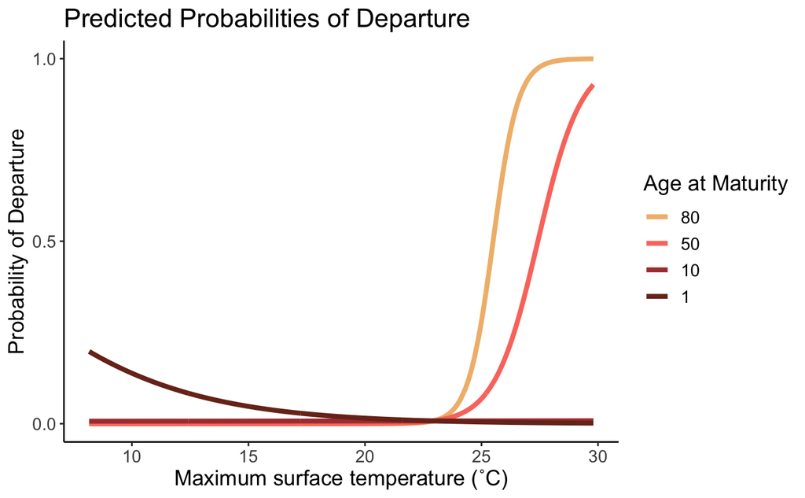

```r
#best model with fish only
mod_ext_trait <- glmer(now_ext ~ max_sst_temp_scaled * age.maturity_scaled + age.max_scaled + (1|reg) + (1|spp), family = "binomial", data = extinction.reduced, nAGQ = 0)

#using best predictor for all species in model instead
mod_ext_trait_allspp <- glmer(now_ext ~ seas_sst_temp_lag3_scaled * age.maturity_scaled + age.max_scaled + (1|reg) + (1|spp), family = "binomial", data = extinction.reduced, nAGQ = 0)

#reverse to agematurity unscaled
mod_ext_reverse_scaled_agematurity <- lm(age.maturity ~ age.maturity_scaled, data = spp_master_ztemp_seus_buoy.traits_scaled)

mod_ext_forward_scaled_agematurity <- lm(age.maturity_scaled ~ age.maturity, data = spp_master_ztemp_seus_buoy.traits_scaled)

age_match <- data.table(ages_we_want = c(1, 10, 50, 80))
age_match[,age.maturity_scaled := ages_we_want * mod_ext_forward_scaled_agematurity$coefficients[2]+mod_ext_forward_scaled_agematurity$coefficients[1]]

#best predictor for fish only: max_sst_temp_change_abs_lag1_scaled as x axis
temp_ext_newdata <- runif(500,min(spp_master_ztemp_seus_buoy.traits_scaled$max_sst_temp_scaled), max(spp_master_ztemp_seus_buoy.traits_scaled$max_sst_temp_scaled))

temp_agematurity_newdata <- age_match[,age.maturity_scaled]


temp_agemax_newdata <- mean(spp_master_ztemp_seus_buoy.traits_scaled$age.max_scaled, na.rm = T)

ext_newdata_traits <- expand.grid("max_sst_temp_scaled" = temp_ext_newdata, "age.maturity_scaled" = temp_agematurity_newdata, "age.max_scaled" = temp_agemax_newdata)


preds <- predict(mod_ext_trait, newdata = ext_newdata_traits, re.form = NA, type = "response")
preds_predictors <- data.table(cbind(ext_newdata_traits, preds))
preds_predictors <- preds_predictors[age_match, on = "age.maturity_scaled"]

#I want x axis to be meaningful
mod_ext_reverse_scaledtemp <- lm(max_sst_temp ~ max_sst_temp_scaled, data = spp_master_ztemp_seus_buoy.traits_scaled)


preds_predictors[,max_sst_temp := mod_ext_reverse_scaledtemp$coefficients[2]*max_sst_temp_scaled + mod_ext_reverse_scaledtemp$coefficients[1] ]

#reverse order of ages to match
preds_predictors$ages_we_want <- factor(preds_predictors$ages_we_want, levels=c("80", "50", "10", "1"))


ggplot(data = preds_predictors, aes(x = max_sst_temp, y = preds, color = as.factor(ages_we_want))) +
  geom_line(size = 1.5) +
  labs(colour="Age at Maturity", x = "Maximum surface temperature (˚C)", y = "Probability of Departure",title = "Predicted Probabilities of Departure") +
  scale_y_continuous(breaks=c(0, 0.5, 1)) +
  theme_classic() +
  scale_color_manual(values = pal) +
  theme(text=element_text(size = 14))

ggsave(path = "plots/marginal_effects", file = "predicted_probs_ext_maxage.jpg")
```

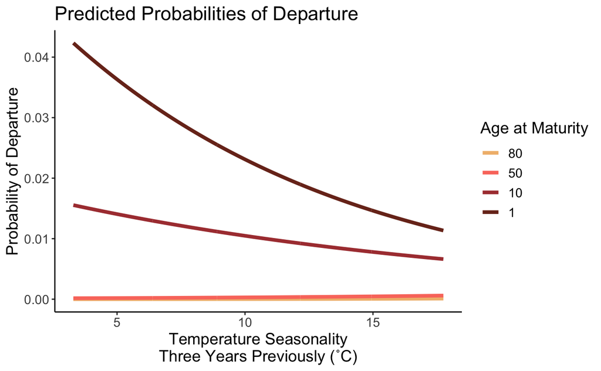

```r
#___________
#best predictor for all organisms: seasonality as x axis, lagged 3 years
temp_ext_newdata_seas <- runif(500,min(spp_master_ztemp_seus_buoy.traits_scaled$seas_sst_temp_lag3_scaled), max(spp_master_ztemp_seus_buoy.traits_scaled$seas_sst_temp_lag3_scaled))

temp_agematurity_newdata_seas <- age_match[,age.maturity_scaled]


temp_agemax_newdata_seas <- mean(spp_master_ztemp_seus_buoy.traits_scaled$age.max_scaled, na.rm = T)

ext_newdata_traits_seas <- expand.grid("seas_sst_temp_lag3_scaled" = temp_ext_newdata_seas, "age.maturity_scaled" = temp_agematurity_newdata_seas, "age.max_scaled" = temp_agemax_newdata_seas)


preds_seas <- predict(mod_ext_trait_allspp, newdata = ext_newdata_traits_seas, re.form = NA, type = "response")
preds_predictors_seas <- data.table(cbind(ext_newdata_traits_seas, preds_seas))
preds_predictors_seas <- preds_predictors_seas[age_match, on = "age.maturity_scaled"]

#I want x axis to be meaningful
mod_ext_reverse_scaledtemp_seas <- lm(seas_sst_temp_lag3 ~ seas_sst_temp_lag3_scaled, data = spp_master_ztemp_seus_buoy.traits_scaled)


preds_predictors_seas[,seas_sst_temp_lag3 := mod_ext_reverse_scaledtemp_seas$coefficients[2]*seas_sst_temp_lag3_scaled + mod_ext_reverse_scaledtemp_seas$coefficients[1] ]

#reverse order of ages to match
preds_predictors_seas$ages_we_want <- factor(preds_predictors_seas$ages_we_want, levels=c("80", "50", "10", "1"))


ggplot(data = preds_predictors_seas, aes(x = seas_sst_temp_lag3, y = preds_seas, color = as.factor(ages_we_want))) +
  geom_line(size = 1.5) +
  labs(colour="Age at Maturity", x = "Temperature Seasonality\nThree Years Previously (˚C)", y = "Probability of Departure",title = "Predicted Probabilities of Departure") +
 # scale_y_continuous(breaks=c(0, 0.5, 1)) +
  theme_classic() +
  scale_color_manual(values = pal) +
  theme(text=element_text(size = 14))

ggsave(path = "plots/marginal_effects", file = "predicted_probs_ext_maxage_seas.jpg")
```